# spiral plot

Wenxi Ye

2024-04-20

## qué es la técnica de visualización spiral plot

Esta visualización representa datos basados en el tiempo a lo largo de una espiral de Arquímedes. El gráfico comienza en el centro de la espiral y luego avanza hacia afuera. Los gráficos de espiral son versátiles y pueden representar barras, líneas o puntos a lo largo del camino espiral.

Los gráficos de espiral son ideales para mostrar grandes conjuntos de datos, generalmente para mostrar tendencias a lo largo de un largo período de tiempo. Por lo tanto, los gráficos de espiral son excelentes para mostrar patrones periódicos. Se puede asignar un color a cada período para dividirlos y permitir cierta comparación entre cada período. Por lo tanto, por ejemplo, si quisiéramos mostrar datos durante un año, podríamos asignar un color para cada mes en el gráfico.

## dataset

https://www.kaggle.com/datasets/josepblasco/hidro-data?select=

Datos de precipitaciones Los datos que emplearé pertenecen a la Agencia Estatal de Meteorología (AEMET), organismo público español encargado de la gestión y prestación de servicios meteorológicos y climáticos. AEMET se dedica a la observación, predicción, elaboración y difusión de información meteorológica y climática en España.

```r
df2021 = read.csv2("PREC_2021_Provincias.csv")
df2020 = read.csv2("PREC_2020_Provincias.csv")
df2019 = read.csv2("PREC_2019_Provincias.csv")
head(df2021)
```

```
##       Parametro   region enero febrero marzo abril  mayo junio julio agosto
## 1 Precipitacion A CORUNA 240.5   293.4  31.0  80.6 149.5 108.9  44.6   21.8
## 2 Precipitacion ALBACETE  68.1    28.0  26.2  65.3  25.4  50.0   2.0   34.5
## 3 Precipitacion ALICANTE  49.2     3.7  63.2  85.8  57.2  20.0   9.2    5.0
## 4 Precipitacion  ALMERIA  56.3     5.2  35.8  43.1  38.8  16.9  10.2    1.9
## 5 Precipitacion    ARABA  96.8    79.9  38.0  52.0  37.7 107.8   8.5   17.7
## 6 Precipitacion ASTURIAS 196.9   138.4  34.4  73.1  67.4 131.2  22.5   19.2
##   septiembre octubre noviembre diciembre  anual
## 1       96.5   154.5     100.8     214.8 1536.9
## 2       48.0    44.8      33.1      14.1  439.5
## 3       44.0    41.1      47.4       1.8  427.6
## 4       17.4    27.3      32.6       3.2  288.7
## 5       63.3    38.5     212.2     197.3  949.7
## 6       90.3    74.2     309.8     205.3 1362.7
```

```r
head(df2020)
```

```
##        Prametro   region enero febrero marzo abril mayo junio julio agosto
## 1 Precipitacion A CORUNA 230.2    94.0 147.5 155.2 45.7  64.9   3.7  117.8
## 2 Precipitacion ALBACETE  57.5     1.3 113.6  60.7 54.1  10.5  16.9    9.3
## 3 Precipitacion ALICANTE 141.2     2.2  95.9  54.4 35.2  23.6   2.5   17.3
## 4 Precipitacion  ALMERIA  43.9     0.6  68.9  34.3 14.5   2.2   2.9    0.6
## 5 Precipitacion    ARABA  46.9    12.2 113.9  75.1 67.5  63.4  12.4   38.9
## 6 Precipitacion ASTURIAS  71.2    30.1 129.0  91.4 68.1  75.6  16.8  110.0
##   septiembre octubre noviembre diciembre  anual
## 1       63.9   203.3     133.8     373.5 1633.5
## 2       15.2    19.5      74.1      34.7  467.4
## 3        9.0     5.1      39.6       4.5  430.5
## 4       17.4     7.4      36.8       1.5  231.0
## 5       75.2   129.4      34.0     188.9  857.8
## 6       73.7   197.5      34.7     339.2 1237.3
```

```r
head(df2019)
```

```
##       parametro   region enero febrero marzo abril mayo junio julio agosto
## 1 Precipitacion A CORUNA 171.2    72.0  96.1 173.7 52.9  78.2  19.6   56.6
## 2 Precipitacion ALBACETE  18.8     5.0  19.4 159.8  8.6   3.8   8.5   24.2
## 3 Precipitacion ALICANTE   2.1     0.8  34.1 180.4  6.2   1.1   0.8   44.6
## 4 Precipitacion  ALMERIA   2.9     4.3  14.2  55.8  1.9   2.0   0.3    1.9
## 5 Precipitacion    ARABA 193.5    49.2  27.6  79.5 61.6  26.5  60.1   23.6
## 6 Precipitacion ASTURIAS 286.6    66.2  46.1 101.5 63.2  72.1  41.2   34.0
##   septiembre octubre noviembre diciembre  anual
## 1       73.2   249.4     393.3     268.8 1705.0
## 2      101.5    25.0      56.8      44.6  476.0
## 3      171.0    47.9      17.8      79.8  586.6
## 4      100.4    24.1      24.5      48.0  280.3
## 5       62.2    63.0     259.7      83.7  990.2
## 6       61.7   163.2     441.5     222.5 1599.8
```

```r
df2021_bcn = df2021[df2021$region=='BARCELONA',]
df2020_bcn = df2020[df2020$region=='BARCELONA',]
df2019_bcn = df2019[df2019$region=='BARCELONA',]

library(tidyr)

# Para el dataframe de 2021
df2021_bcn_long <- gather(df2021_bcn, mes, valor, -region)
df2021_bcn_long$anio <- 2021

# Para el dataframe de 2020
df2020_bcn_long <- gather(df2020_bcn, mes, valor, -region)
df2020_bcn_long$anio <- 2020

# Para el dataframe de 2019
df2019_bcn_long <- gather(df2019_bcn, mes, valor, -region)
df2019_bcn_long$anio <- 2019

# Combinamos los dataframes en uno solo
df_bcn <- rbind(df2021_bcn_long, df2020_bcn_long, df2019_bcn_long)

# Reordenamos las columnas
df_bcn <- df_bcn[, c("mes", "anio", "valor")]

print(df_bcn)
```

```
##           mes anio         valor
## 1   Parametro 2021 Precipitacion
## 2       enero 2021          26.8
## 3     febrero 2021          28.4
## 4       marzo 2021          16.4
## 5       abril 2021          72.2
## 6        mayo 2021          26.0
## 7       junio 2021          42.3
## 8       julio 2021          18.7
## 9      agosto 2021          25.7
## 10 septiembre 2021          76.0
## 11    octubre 2021          40.6
## 12  noviembre 2021          72.8
## 13  diciembre 2021           2.2
## 14      anual 2021         448.1
```

[output cut: 28 more lines]

```r
library(dplyr)
# Eliminamos filas que contienen la palabra "Parametro" en la columna "mes"
df_bcn <- df_bcn %>%
  filter(!grepl("Precipitacion", valor))

# Eliminamos filas que contienen la palabra "anual" en la columna "mes"
df_bcn <- df_bcn %>%
  filter(!grepl("anual", mes))

# Vector de nombres de los meses
nombres_meses <- c("enero", "febrero", "marzo", "abril", "mayo", "junio", "julio", "agosto", "septiembre", "octubre", "noviembre", "diciembre")

# Transformamos los nombres de los meses en números del 1 al 12
df_bcn$mes <- match(df_bcn$mes, nombres_meses)

# Imprimimos el dataframe resultante
print(df_bcn)
```

```
##    mes anio valor
## 1    1 2021  26.8
## 2    2 2021  28.4
## 3    3 2021  16.4
## 4    4 2021  72.2
## 5    5 2021  26.0
## 6    6 2021  42.3
## 7    7 2021  18.7
## 8    8 2021  25.7
## 9    9 2021  76.0
## 10  10 2021  40.6
## 11  11 2021  72.8
## 12  12 2021   2.2
## 13   1 2020 153.9
## 14   2 2020   1.7
```

[output cut: 22 more lines]

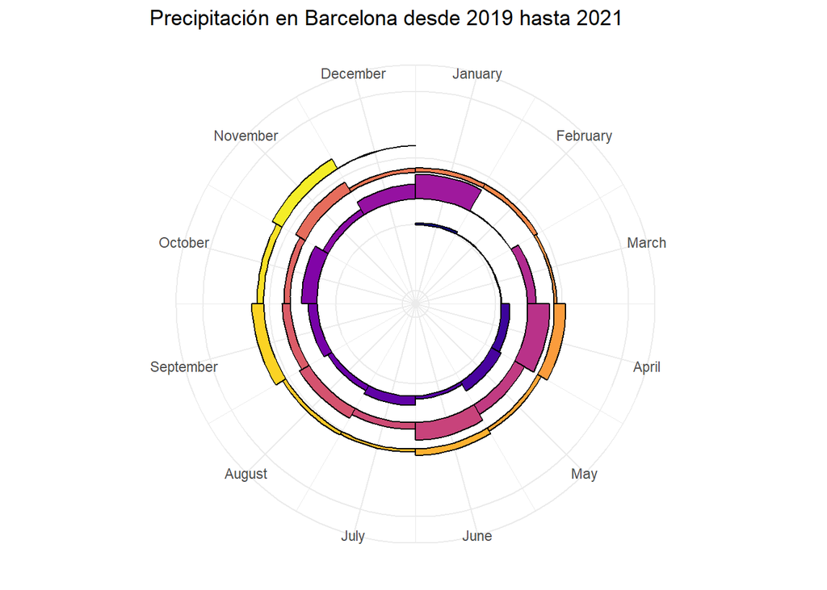

```r
library(ggplot2)
library(dplyr)

# Convertimos el año en factor
df_bcn$anio <- as.factor(df_bcn$anio)
df_bcn$valor <- as.numeric(df_bcn$valor)

# Calcular la posición en y para cada año y mes
df_bcn <- df_bcn %>%
  mutate(y = as.numeric(anio) - 1 + (as.numeric(mes) - 1) / 12)

# Definimos los niveles de month como números del 1 al 12
df_bcn$mes <- factor(df_bcn$mes, levels = 1:12)

bars <- df_bcn %>%
  mutate(value_norm = valor / (max(valor) * 1.1),
         xmin = as.numeric(mes) - 0.5,
         xmax = as.numeric(mes) + 0.5,
         ymin = y,
         ymax = y + value_norm)

# Convertimos las barras en polígonos
poly <- bars %>%
  rowwise() %>%
  do(with(., tibble(year = anio,
                     month = mes,
                     x = c(xmin, xmax, xmax, xmin),
                     y = c(ymin - 1/24,
                           ymin + 1/24,
                           ymax + 1/24,
                           ymax - 1/24))))

# Creamos el gráfico de espiral
ggplot(poly, aes(x, y, fill = interaction(factor(month, levels = 1:12), year))) +
  geom_polygon(col = 1) +
  coord_polar() +
  ylim(-3, 5) +
  viridis::scale_fill_viridis(discrete = TRUE, option = 'C') +
  scale_x_continuous(breaks = 1:12, labels = month.name) +
  labs( title = "Precipitación en Barcelona desde 2019 hasta 2021") +

  theme_minimal() +
  theme(legend.position = "none", axis.text.y = element_blank(), axis.title = element_blank())
```